# **GH1019657**

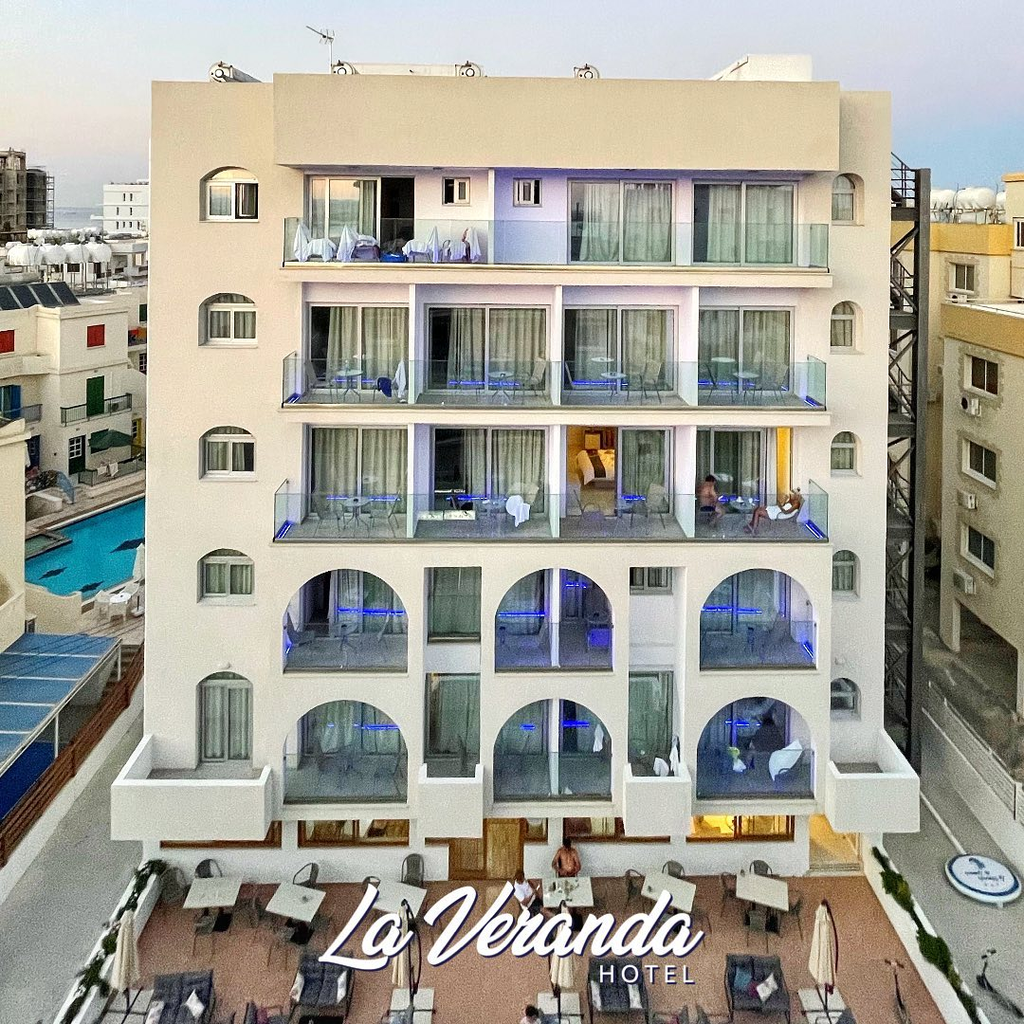

```python
from IPython.display import display, Image
image_address = "/content/La Veranda.jpeg"
image = Image(filename=image_address, width=700)
display(image)
```

# **Introduction**

### The dataset I have chosen is a hotel dataset which consists of 1523 rows and 11 columns.

### La Veranda hotel is a 3 star hotel located in the city of Larnaca, Cyprus. The hotel is surrounded by some residential areas and walking distance to a beach and supermarkets which makes it a quiet perfect location to spend vacation time. The hotel offers elegantly decorated rooms and suites with modern amenities. La Veranda is the ideal destination for family, friends and couples seeking a peaceful and relaxing retreat in a stunning natural setting.

# **Problem**

### Need to understand customer behavior their experience at the hotel and identifying areas for improvement.

### Importing necessary libraries for Data Exploration, cleaning and further analysis

```python
import pandas as pd
import matplotlib.pyplot as plt
import seaborn as sns
```

# **Data Exploration**

### Below we will explore the dataset by checking the shape/size of the dataset, some extra information about the dataset, we will also use descriptive statistics for more information and also we will check for missing values using some functions from pandas library.

```python
df = pd.read_csv("La_Veranda_Reviews-2023-01-16.csv", encoding='unicode_escape')
df.head()
```

|  | Title | PositiveReview | NegativeReview | Score | GuestName | GuestCountry | RoomType | NumberOfNights | VisitDate | GroupType | PropertyResponse |
| --- | --- | --- | --- | --- | --- | --- | --- | --- | --- | --- | --- |
| 0 | Wonderful place to stay. | New, comfortable apartments, close to the airp... | Nothing at all. | 10.0 | Olga | Norway | Budget Twin Room | 1 night | June 2022 | Solo traveler | NaN |
| 1 | It was superb | We had a really pleasant stay! The staff was v... | NaN | 10.0 | Iwona | Poland | Double Room | 3 nights | December 2022 | Family | NaN |
| 2 | Very Good | the location is great and near the airport. bu... | NaN | 8.0 | Ruijia | Sweden | Double Room | 1 night | December 2022 | Solo traveler | NaN |
| 3 | Wonderful | Great stuff\nGreat Quality/price\nClean | NaN | 9.0 | Theprincem | United Kingdom | Double Room with Balcony | 2 nights | September 2022 | Solo traveler | NaN |
| 4 | Fantastic value for a new, modern and spotless... | Clean and modern with very comfortable beds, i... | NaN | 10.0 | M | Switzerland | Family Suite with Balcony | 1 night | October 2022 | Family | NaN |

### The size of the dataset i.e we have 1523 rows and 11 columns

```python
df.shape
```

```
(1523, 11)
```

### The .info() will give us the information about each column in the dataset

```python
df.info()
```

```
<class 'pandas.core.frame.DataFrame'>
RangeIndex: 1523 entries, 0 to 1522
Data columns (total 11 columns):
 #   Column            Non-Null Count  Dtype
---  ------            --------------  -----
 0   Title             1521 non-null   object
 1   PositiveReview    775 non-null    object
 2   NegativeReview    435 non-null    object
 3   Score             1523 non-null   float64
 4   GuestName         1523 non-null   object
 5   GuestCountry      1523 non-null   object
 6   RoomType          1460 non-null   object
 7   NumberOfNights    1523 non-null   object
 8   VisitDate         1523 non-null   object
 9   GroupType         1523 non-null   object
 10  PropertyResponse  123 non-null    object
dtypes: float64(1), object(10)
memory usage: 131.0+ KB
```

### Descriptive Statistics - This will give some extra information about the dataset such as the total count of values of every column, mean, standard deviation etc.

```python
df.describe()
```

|  | Score |
| --- | --- |
| count | 1523.000000 |
| mean | 8.973802 |
| std | 1.300178 |
| min | 1.000000 |
| 25% | 8.000000 |
| 50% | 9.000000 |
| 75% | 10.000000 |
| max | 10.000000 |

### This will check the missing values in each column of the dataset

```python
df.isna().sum()
```

```
Title                  2
PositiveReview       748
NegativeReview      1088
Score                  0
GuestName              0
GuestCountry           0
RoomType              63
NumberOfNights         0
VisitDate              0
GroupType              0
PropertyResponse    1400
dtype: int64
```

### This will give the total number of missing values in the dataset

```python
df.isnull().sum().sum()
```

```
3301
```

### Using heatmap from seaborn library we will visualize the missing values in each column of the dataset.

### Here, White lines are the missing values and Black is for the non-missing values.

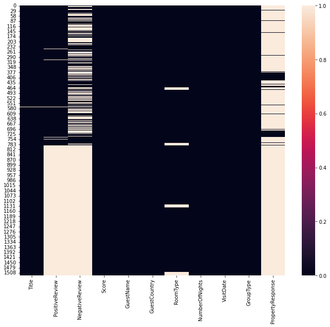

```python
plt.figure(figsize = (12,10))
sns.heatmap(df.isnull())
```

### Now we will also check the missing values in each column, using a bar chart for better understanding.

### The below code starts by using matplotlib library for using the bar chart where we will set the figure size, then we will define a variable 'missing_vals' which will keep the sum of the total number of missing values in the whole dataset, then we will set the graph as 'bar' and also the x-axis, y-axis and title labels respectively. Followed by a for loop which will add the values to each bars i.e columns for better understanding about the missing values.

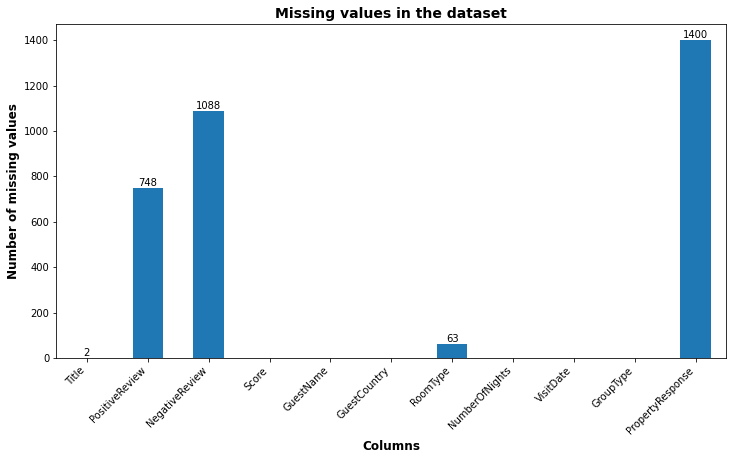

```python
# Create a bar chart of the missing values in each column
plt.figure(figsize=(12,8))
missing_vals = df.isnull().sum()
missing_vals.plot(kind='bar')
plt.xlabel('Columns', fontsize = 12, fontweight = 'bold')
plt.xticks(rotation=45, ha='right')
plt.subplots_adjust(bottom=0.3)
plt.ylabel('Number of missing values',fontsize = 12, fontweight = 'bold')
plt.title('Missing values in the dataset', fontsize = 14, fontweight = 'bold')
# add value labels to bars
for i, val in enumerate(missing_vals):
  if val > 0:
    plt.annotate(str(val), xy=(i, val), ha='center', va='bottom')
plt.show()
```

### With the help of the pandas function (.dtypes) we will check the data types of each columns

```python
df.dtypes
```

```
Title                object
PositiveReview       object
NegativeReview       object
Score               float64
GuestName            object
GuestCountry         object
RoomType             object
NumberOfNights       object
VisitDate            object
GroupType            object
PropertyResponse     object
dtype: object
```

# Data Cleaning

### As we have explored the dataset above we will try to clean the dataset by removing or replacing it with some values.

### As the 'PropertyResponse' column has the most missing values we will drop that column. Followed by the 'GuestName' which seems to be unnecessary for further analysis we will also drop this column. So now we have 9 columns in the dataset.

```python
df.drop("PropertyResponse", axis = 1, inplace = True)
df.drop("GuestName", axis = 1, inplace = True)
```

### Now we will try to fill the missing values with the mean of that column which is obviusly the 'Score' column as it the only column with numerical values.

```python
# Fill in missing values with mean
df = df.fillna(df.mean())
```

```python
df
```

|  | Title | PositiveReview | NegativeReview | Score | GuestCountry | RoomType | NumberOfNights | VisitDate | GroupType |
| --- | --- | --- | --- | --- | --- | --- | --- | --- | --- |
| 0 | Wonderful place to stay. | New, comfortable apartments, close to the airp... | Nothing at all. | 10.0 | Norway | Budget Twin Room | 1 night | June 2022 | Solo traveler |
| 1 | It was superb | We had a really pleasant stay! The staff was v... | NaN | 10.0 | Poland | Double Room | 3 nights | December 2022 | Family |
| 2 | Very Good | the location is great and near the airport. bu... | NaN | 8.0 | Sweden | Double Room | 1 night | December 2022 | Solo traveler |
| 3 | Wonderful | Great stuff\nGreat Quality/price\nClean | NaN | 9.0 | United Kingdom | Double Room with Balcony | 2 nights | September 2022 | Solo traveler |
| 4 | Fantastic value for a new, modern and spotless... | Clean and modern with very comfortable beds, i... | NaN | 10.0 | Switzerland | Family Suite with Balcony | 1 night | October 2022 | Family |
| ... | ... | ... | ... | ... | ... | ... | ... | ... | ... |
| 1518 | Exceptional | NaN | NaN | 10.0 | Israel | NaN | 5 nights | September 2021 | Couple |
| 1519 | Wonderful | NaN | NaN | 9.0 | Czech Republic | NaN | 1 night | September 2021 | Group |
| 1520 | Very Good | NaN | NaN | 8.0 | Sweden | NaN | 1 night | August 2021 | Couple |
| 1521 | Wonderful | NaN | NaN | 9.0 | Germany | NaN | 3 nights | September 2021 | Solo traveler |
| 1522 | Pleasant | NaN | NaN | 6.0 | Austria | NaN | 1 night | October 2022 | Couple |

1523 rows × 9 columns

### Now as some of the columns does not have a relevant datatype which will make the further analysis difficult, we will try to convert the data types for easier approch.

```python
df.dtypes
```

```
Title              object
PositiveReview     object
NegativeReview     object
Score             float64
GuestCountry       object
RoomType           object
NumberOfNights     object
VisitDate          object
GroupType          object
dtype: object
```

### Using the .convert_dtypes() from pandas library, this will convert the datatype of each column to the most appropriate data type.

```python
df = df.convert_dtypes()
df.dtypes
```

```
Title              string
PositiveReview     string
NegativeReview     string
Score             Float64
GuestCountry       string
RoomType           string
NumberOfNights     string
VisitDate          string
GroupType          string
dtype: object
```

### As we have seen there are some missing values in the 'Title' and 'RoomType' columns as these columns are relevant so we will not drop these columns but we will remove the rows which are missing in these columns using the .dropna() from pandas.

```python
# Drop missing rows from GuestCountry and GroupType columns
df.dropna(subset=['Title', 'RoomType'], inplace=True)
```

### In the below block of code we will define a function 'text_cleaner' which will using the regular expression and string libraries and will take text as an input and will convert the text to lowercase, then it removes all characters that are not letters or whitespace using the re.sub() method "r'[^a-zA-Z\s]" then using "r'\s+" will replace the string as ' '. Then the function (text_cleaner) will return the cleaned string. Using the lambda funtion will call the function by giving the text as an input. Then with the help of this function we will clean the text of 'Title', 'PositiveReview' and 'NegativeReview' columns as they are relevant for further analysis. Finally we will check the columns in the dataset by using .head().

```python
import re
import string
def text_cleaner(text):
  if isinstance(text, str):
    text = text.lower()
    text = re.sub(r'[^a-zA-Z\s]', '', text)
    text = re.sub(r'\s+', ' ', text)
    return text.strip()
cleaner = lambda x: text_cleaner(x)

df['Title'] = pd.DataFrame(df['Title'].apply(cleaner))
df['PositiveReview'] = pd.DataFrame(df['PositiveReview'].apply(cleaner))
df['NegativeReview'] = pd.DataFrame(df['NegativeReview'].apply(cleaner))
df.head(5)
```

|  | Title | PositiveReview | NegativeReview | Score | GuestCountry | RoomType | NumberOfNights | VisitDate | GroupType |
| --- | --- | --- | --- | --- | --- | --- | --- | --- | --- |
| 0 | wonderful place to stay | new comfortable apartments close to the airpor... | nothing at all | 10.0 | Norway | Budget Twin Room | 1 night | June 2022 | Solo traveler |
| 1 | it was superb | we had a really pleasant stay the staff was ve... | None | 10.0 | Poland | Double Room | 3 nights | December 2022 | Family |
| 2 | very good | the location is great and near the airport bus... | None | 8.0 | Sweden | Double Room | 1 night | December 2022 | Solo traveler |
| 3 | wonderful | great stuff great qualityprice clean | None | 9.0 | United Kingdom | Double Room with Balcony | 2 nights | September 2022 | Solo traveler |
| 4 | fantastic value for a new modern and spotless ... | clean and modern with very comfortable beds in... | None | 10.0 | Switzerland | Family Suite with Balcony | 1 night | October 2022 | Family |

### As there are rows in the 'PositiveReview', 'NegativeReview' and 'RoomType' columns which are missing we will replace it with 'NA' using the .fillna() from the pandas library

```python
# replace missing values with "NA"
df["PositiveReview"] = df["PositiveReview"].fillna("NA")

# display the updated dataset
df['PositiveReview'].head(10)
```

```
0    new comfortable apartments close to the airpor...
1    we had a really pleasant stay the staff was ve...
2    the location is great and near the airport bus...
3                 great stuff great qualityprice clean
4    clean and modern with very comfortable beds in...
5    we only stayed over night before heading to th...
6                                                great
7              nice location lovely personal renovated
8    couldnt eat breakfast due to dietary restricti...
9    great modern room comfortable bed and quiet lo...
Name: PositiveReview, dtype: object
```

```python
# replace missing values with "NA"
df["NegativeReview"] = df["NegativeReview"].fillna("NA")

# display the updated dataset
df['NegativeReview'].head(10)
```

```
0                                       nothing at all
1                                                   NA
2                                                   NA
3                                                   NA
4                                                   NA
5                                                   NA
6                                                   NA
7                                              nothing
8    maybe possibility of purchasing fresh fruit or...
9                                                   NA
Name: NegativeReview, dtype: object
```

```python
df['RoomType'] = df['RoomType'].fillna('Unknown')
df['RoomType'].head(10)
```

```
0             Budget Twin Room
1                  Double Room
2                  Double Room
3     Double Room with Balcony
4    Family Suite with Balcony
5     Double Room with Balcony
6            Two-Bedroom Suite
7                  Double Room
8                  Double Room
9                  Double Room
Name: RoomType, dtype: string
```

### Checking the new changes which we have made till now.

```python
df
```

|  | Title | PositiveReview | NegativeReview | Score | GuestCountry | RoomType | NumberOfNights | VisitDate | GroupType |
| --- | --- | --- | --- | --- | --- | --- | --- | --- | --- |
| 0 | wonderful place to stay | new comfortable apartments close to the airpor... | nothing at all | 10.0 | Norway | Budget Twin Room | 1 night | June 2022 | Solo traveler |
| 1 | it was superb | we had a really pleasant stay the staff was ve... | NA | 10.0 | Poland | Double Room | 3 nights | December 2022 | Family |
| 2 | very good | the location is great and near the airport bus... | NA | 8.0 | Sweden | Double Room | 1 night | December 2022 | Solo traveler |
| 3 | wonderful | great stuff great qualityprice clean | NA | 9.0 | United Kingdom | Double Room with Balcony | 2 nights | September 2022 | Solo traveler |
| 4 | fantastic value for a new modern and spotless ... | clean and modern with very comfortable beds in... | NA | 10.0 | Switzerland | Family Suite with Balcony | 1 night | October 2022 | Family |
| ... | ... | ... | ... | ... | ... | ... | ... | ... | ... |
| 1499 | good | NA | NA | 7.0 | Italy | Double Room | 1 night | August 2021 | Couple |
| 1500 | good | NA | NA | 7.0 | Russia | Double Room with Balcony | 1 night | September 2021 | Couple |
| 1501 | good | NA | NA | 7.0 | France | Double Room with Balcony | 1 night | August 2021 | Couple |
| 1502 | good | NA | NA | 7.0 | Denmark | Double Room with Balcony | 1 night | August 2021 | Group |
| 1503 | good | NA | NA | 7.0 | Russia | Double Room with Balcony | 1 night | June 2021 | Couple |

1458 rows × 9 columns

### Checking the missing values in each column using the .isnull().sum() method from the pandas library. As we can see the dataset has no missing values left we will start the further analysis.

```python
df.isnull().sum()
```

```
Title             0
PositiveReview    0
NegativeReview    0
Score             0
GuestCountry      0
RoomType          0
NumberOfNights    0
VisitDate         0
GroupType         0
dtype: int64
```

# **Data Visualization**

### The dataset is cleaned now, we will try to visualize the 'Score' column in the below block of code by defining a variable which will keep the value count of the 'Score' column then using the matplotlib library we will plot the bar graph by giving the figure size, x-axis, y-axis and their lables respectively.

### The output we will get shows the 'Score' vs 'Count' which shows that count for 10 scores/ratings are the highest which means that the customers are satisfied with the experience in the hotel.

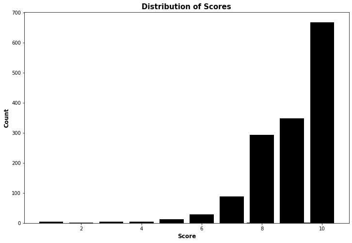

```python
# Calculate the count of each value in the 'Score' column
value_counts = df['Score'].value_counts()

# Create a bar chart
fig, ax = plt.subplots(figsize=(12, 8))
ax.bar(value_counts.index, value_counts.values, color='black')

# Set the x-axis and y-axis labels and title
ax.set_xlabel('Score', fontsize=12, fontweight='bold')
ax.set_ylabel('Count', fontsize=12, fontweight='bold')
ax.set_title('Distribution of Scores', fontsize=15, fontweight='bold')
plt.show()
```

### Using the .value_counts() method from the pandas library we will check the counts of 'Score' column it will help us to understand each value better.

```python
df['Score'].value_counts()
```

```
10.0    668
9.0     348
8.0     293
7.0      89
6.0      29
5.0      13
4.0       5
3.0       4
1.0       4
9.6       2
2.0       2
7.9       1
Name: Score, dtype: Int64
```

### As 'NumberOfNights' column is also important to understand the business better with the help of .value_counts() method from pandas library we will see the number of nigths customers stay at the hotel most.

```python
df['NumberOfNights'].value_counts()
```

```
1 night      1109
2 nights      135
3 nights       88
4 nights       52
7 nights       31
5 nights       14
9 nights       10
6 nights        5
11 nights       3
8 nights        3
14 nights       3
12 nights       2
10 nights       1
16 nights       1
15 nights       1
Name: NumberOfNights, dtype: Int64
```

### For clear understanding we will also visualize the 'NumberOfNights' column by using the marplotlib library and will set the figure size, x-axis, y-axis, title and their labels respectively and also the x-axis lables using the xticks funtion from matplotlib by rotating the lables by 45 degress and in the right align and then will show it.

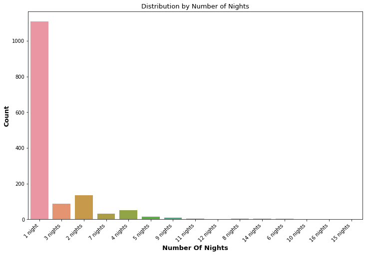

```python
# Create the countplot
plt.figure(figsize=(12, 10))
ax = sns.countplot(data=df, x ='NumberOfNights')
ax.set_xlabel('Number Of Nights', fontsize = 13, fontweight = 'bold')
ax.set_ylabel('Count', fontsize = 13, fontweight = 'bold')
ax.set_title('Distribution by Number of Nights', fontsize = 13)
plt.xticks(rotation=45, ha='right')
plt.subplots_adjust(bottom=0.3)
plt.show()
```

### Checking the value counts for 'VisitDate' column, as we can see that most of the customers has visited in October in 2022. The numbers are increasing gradually every year.

```python
df['VisitDate'].value_counts()
```

```
October 2022      162
September 2022    128
June 2022         127
July 2022         126
August 2022       122
October 2021       92
August 2021        91
May 2022           89
November 2022      87
April 2022         82
July 2021          78
September 2021     78
November 2021      49
June 2021          40
December 2022      31
December 2021      22
March 2022         21
February 2022      19
January 2022       10
May 2021            4
Name: VisitDate, dtype: Int64
```

### Visualizing the same 'VisitDate' column for better understanding. Beginning with the conversion of the datatype of this column we will convert the datatype of 'VisitDate' column into datetime format and will save the changes in the original dataset as well. Followed by defining a variable which will create a group using .groupby from pandas library and it will have the count of the 'VisitDate' and 'Score' column. Then we will plot a line graph using matplotlib library and setting the x-axis, y-axis, title and their labels respectively.

### The output shows that during January till March in 2022 the distribution is less it means less customers visited the hotel but eventually it increased in April and it keep going up till October 2022.

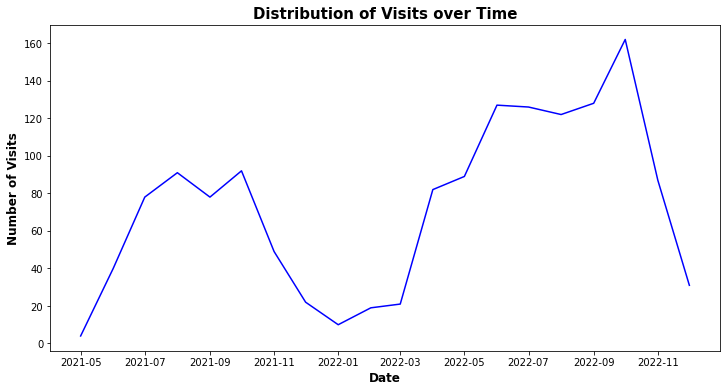

```python
# Convert VisitDate column to datetime format
df['VisitDate'] = pd.to_datetime(df['VisitDate'])

# Group the visits by date and count the number of visits for each date
visits_per_day = df.groupby('VisitDate')['Score'].count()

# Create a line plot
fig, ax = plt.subplots(figsize=(12, 6))
ax.plot(visits_per_day.index, visits_per_day.values, color='blue')
ax.set_xlabel('Date', fontsize=12, fontweight='bold')
ax.set_ylabel('Number of Visits', fontsize=12, fontweight='bold')
ax.set_title('Distribution of Visits over Time', fontsize=15, fontweight='bold')
plt.show()
```

### Now we need to know what type of customers stay in La Veranda hotel, checking the value_counts first, as we can see Couples visits/stay at this hotel the most followed by families.

```python
df['GroupType'].value_counts()
```

```
Couple           511
Family           394
Solo traveler    382
Group            171
Name: GroupType, dtype: Int64
```

### For better understanding we will also visualize this column and check each group type. The below code begins by defining a variable which will keep the value counts of the 'GroupType' column and with the help of it we will plot a bar graph for each group.

### The output shows that most of the visited customers at this hotel are Couples and the least are Groups, and in the above analysis we have seen that most of the customers stay for 1 night at the hotel.

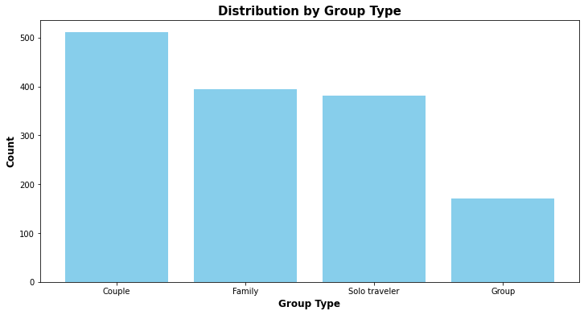

```python
# Count the number of occurrences of each group type
group_counts = df['GroupType'].value_counts()

# Create a bar chart
fig, ax = plt.subplots(figsize=(12, 6))
ax.bar(group_counts.index, group_counts.values, color='skyblue')
ax.set_xlabel('Group Type', fontsize = 12, fontweight='bold')
ax.set_ylabel('Count', fontsize = 12, fontweight='bold')
ax.set_title('Distribution by Group Type', fontsize=15, fontweight='bold')
plt.show()
```

### Now it is also important to know that from which countries the customers are coming from at the hotel to stay. For that we already have 'GuestCountry' column in our dataset. Using the value_count() method we will check the countries, and we can see customers are mostly from United Kingdom.

```python
df['GuestCountry'].value_counts()
```

```
United Kingdom     229
Cyprus             175
Israel             127
France              93
Germany             87
                  ...
North Macedonia      1
Ghana                1
South Korea          1
Angola               1
Nigeria              1
Name: GuestCountry, Length: 68, dtype: Int64
```

### In the above code there are many countries which we have seen for better understanding we will try to know the top 10 countries where the customers come from at La Veranda hotel.

### Beginning by defining a variable which will keep the value counts of 'GuestCountry' column as well as the highest frequency numbers of countries using .nlargest(10) from the pandas library. With the help of this we will plot a bar graph and see which are 10 countries are.

### The output shows most of the customers are from United Kingdom and the least from Italy.

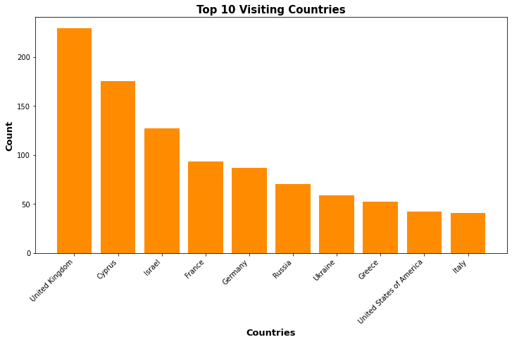

```python
# Get the top 10 highest visiting countries
top_countries = df['GuestCountry'].value_counts().nlargest(10)

# Create a bar chart
fig, ax = plt.subplots(figsize=(12, 8))
ax.bar(top_countries.index, top_countries.values, color='darkorange')
ax.set_xlabel('Countries', fontsize = 13, fontweight = 'bold')
ax.set_ylabel('Count', fontsize = 13, fontweight = 'bold')
ax.set_title('Top 10 Visiting Countries', fontsize=15, fontweight='bold')
plt.xticks(rotation=45, ha='right')
plt.subplots_adjust(bottom=0.3)
plt.show()
plt.show()
```

### We will check the shape after cleaning/removing some values such rows and columns from the dataset.

```python
df.shape
```

```
(1458, 9)
```

### Using the natural language processing library to understand the type of Reviews and customers feedback about the hotel. The below code begins by importing the TextBlob library and defining a function as get_sentiment which takes text as an input and returns two values sentiment polarity and subjectivity. Then the code then applies this function to two columns in the dataframe called 'PositiveReview' and 'NegativeReview', and creates new columns in the dataframe called 'PositiveSentiment', 'PositiveSubjectivity', 'NegativeSentiment', and 'NegativeSubjectivity', which are the results of applying the 'get_sentiment' function to the 'PositiveReview' and 'NegativeReview' columns. Then using the .head() method from pandas library we will print the dataframe.

```python
from textblob import TextBlob
# create a function to get sentiment polarity and subjectivity
def get_sentiment(text):
    blob = TextBlob(text)
    sentiment = blob.sentiment.polarity
    subjectivity = blob.sentiment.subjectivity
    return sentiment, subjectivity

# create new columns for sentiment polarity and subjectivity
df['PositiveSentiment'] = df['PositiveReview'].apply(lambda x: get_sentiment(x)[0])
df['PositiveSubjectivity'] = df['PositiveReview'].apply(lambda x: get_sentiment(x)[1])
df['NegativeSentiment'] = df['NegativeReview'].apply(lambda x: get_sentiment(x)[0])
df['NegativeSubjectivity'] = df['NegativeReview'].apply(lambda x: get_sentiment(x)[1])
```

```python
df.head()
```

|  | Title | PositiveReview | NegativeReview | Score | GuestCountry | RoomType | NumberOfNights | VisitDate | GroupType | PositiveSentiment | PositiveSubjectivity | NegativeSentiment | NegativeSubjectivity |
| --- | --- | --- | --- | --- | --- | --- | --- | --- | --- | --- | --- | --- | --- |
| 0 | wonderful place to stay | new comfortable apartments close to the airpor... | nothing at all | 10.0 | Norway | Budget Twin Room | 1 night | 2022-06-01 | Solo traveler | 0.230152 | 0.736801 | 0.0 | 0.0 |
| 1 | it was superb | we had a really pleasant stay the staff was ve... | NA | 10.0 | Poland | Double Room | 3 nights | 2022-12-01 | Family | 0.372500 | 0.689722 | 0.0 | 0.0 |
| 2 | very good | the location is great and near the airport bus... | NA | 8.0 | Sweden | Double Room | 1 night | 2022-12-01 | Solo traveler | 0.366667 | 0.483333 | 0.0 | 0.0 |
| 3 | wonderful | great stuff great qualityprice clean | NA | 9.0 | United Kingdom | Double Room with Balcony | 2 nights | 2022-09-01 | Solo traveler | 0.655556 | 0.733333 | 0.0 | 0.0 |
| 4 | fantastic value for a new modern and spotless ... | clean and modern with very comfortable beds in... | NA | 10.0 | Switzerland | Family Suite with Balcony | 1 night | 2022-10-01 | Family | 0.390000 | 0.672917 | 0.0 | 0.0 |

### The below code will visualize the above analysis we did to understand the sentiment analysis better. Using the nltk, matplotlib and pandas library we will visualize a histogram for the sentiment analysis of Positive Reviews.

### As the gray part in the graph is in the middle of the graph which means that the reviews are neither positive nor negative and the green bars show that the positive reviews are higher than the negaitve ones as they are in increasing mode and on the right side of the graph.

```python
import nltk
nltk.download('vader_lexicon')
```

```
True
```

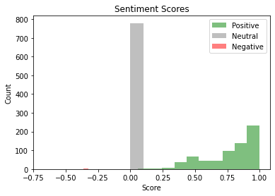

```python
import nltk
import pandas as pd
import matplotlib.pyplot as plt
from nltk.sentiment.vader import SentimentIntensityAnalyzer

# Create a new column for the overall sentiment score
sid = SentimentIntensityAnalyzer()
df['Sentiment'] = df['PositiveReview'].apply(lambda x: sid.polarity_scores(x)['compound'])

# Create histograms of the sentiment scores
plt.hist(df[df['Sentiment'] > 0]['Sentiment'], color='green', alpha=0.5, label='Positive')
plt.hist(df[df['Sentiment'] == 0]['Sentiment'], color='gray', alpha=0.5, label='Neutral')
plt.hist(df[df['Sentiment'] < 0]['Sentiment'], color='red', alpha=0.5, label='Negative')
plt.legend()
plt.title('Sentiment Scores')
plt.xlabel('Score')
plt.ylabel('Count')
plt.show()
```

# **Data Preproccessing**

```python
from sklearn.compose import make_column_transformer
from sklearn.pipeline import make_pipeline
from sklearn.model_selection import train_test_split
from sklearn.preprocessing import LabelEncoder, StandardScaler, OneHotEncoder

# Split the dataset into features as X and target as y
X = df.drop('GuestCountry','Score', axis=1)
y = df['Score']

# Define the column transformer to apply the preprocessing steps to the numeric and categorical features
preprocessor = make_column_transformer(
    (StandardScaler(), X.select_dtypes(include=['float64', 'int64']).columns),
    (OneHotEncoder(handle_unknown='ignore'), X.select_dtypes(include=['object']).columns)
)

# Split the dataset into training and test sets
X_train, X_test, y_train, y_test = train_test_split(X, y, test_size=0.3)

# Fit the preprocessor to the training data and transform both the training and test data
X_train = preprocessor.fit_transform(X_train)
X_test = preprocessor.transform(X_test)

# Print the shape of the train and test sets
print(f"Training set shape: X_train {X_train.shape}")
print(f"Testing set shape: X_test {X_test.shape}")
```

```
Training set shape: X_train (1020, 1047)
Testing set shape: X_test (438, 1047)
```

# Modelling

### Now we will demonstrate the best score and best hyperparameter using KNeighborsRegressor and GridSearchCV with cross-validation which will be helpful to avoid overfitting the hyperparameters to a particular set of data and also to select the optimal model for prediction.

```python
from sklearn.neighbors import KNeighborsRegressor
from sklearn.model_selection import GridSearchCV, train_test_split
from sklearn.pipeline import make_pipeline

# Define the KNN model
knn = KNeighborsRegressor()

# Define the hyperparameters to search over
param_grid = {
    'n_neighbors': [3, 5, 7, 9],
    'weights': ['uniform', 'distance']
}

# Define the grid search object
grid_search = GridSearchCV(knn, param_grid, cv=5)

# Define the pipeline
pipeline = make_pipeline(preprocessor, grid_search)

# Fit the pipeline to the training data
pipeline.fit(X_train, y_train)

# Print the best score and hyperparameters
print("Best score: {:.2f}".format(grid_search.best_score_))
print("Best hyperparameters:", grid_search.best_params_)
```

```
Best score: 0.52
Best hyperparameters: {'n_neighbors': 9, 'weights': 'distance'}
```

```python
from sklearn.tree import DecisionTreeClassifier

# Define the binning thresholds and categories
bins = [-float('inf'), 5, 7, 10, float('inf')]
labels = ['very_low', 'low', 'medium', 'high']

# Bin the continuous target variable into discrete categories
y_binned = pd.cut(y, bins=bins, labels=labels)

# Create a pipeline to apply the preprocessing steps and train the decision tree classifier
pipeline = make_pipeline(preprocessor, DecisionTreeClassifier())

# Fit the pipeline to the training data
pipeline.fit(X_train, y_train)

# Evaluate the performance of the classifier on the test data
score = pipeline.score(X_test, y_test)

print(f"Test accuracy: {score:.2f}")
```

```
Test accuracy: 0.96
```

### The below code begins by importing the accuracy_score library from sklearn then it defines the y_train_pred and y_test_pred which uses the predict method of the pipeline to obtain the predicted categories for the target variable on both the training and test sets. Then, it uses the accuracy_score function to compute the accuracy of the predictions, given the true categories in y_train and y_test. Finally, the code prints the training and test accuracy scores rounded to 2 decimal places.

```python
from sklearn.metrics import accuracy_score

# Predict y_train and y_test
y_train_pred = pipeline.predict(X_train)
y_test_pred = pipeline.predict(X_test)

# Calculate accuracy score for y_train and y_test
train_acc = accuracy_score(y_train, y_train_pred)
test_acc = accuracy_score(y_test, y_test_pred)

print(f"Train accuracy: {train_acc:.2f}")
print(f"Test accuracy: {test_acc:.2f}")
```

```
Train accuracy: 1.00
Test accuracy: 0.96
```

### The below code is evaluating the performance of the Decision Tree Classifier.

### The code begins by defining y_train_pred and y_test_pred variables which will use the predict() method of the pipeline object to make predictions on the training set (X_train) and test set (X_test). Next, the code calculates the train accuracy and test accuracy using the accuracy_score function from sklearn library. After that, it calculates the error rate for the predictions made on the training set and test set by subtracting the accuracy score from 1. Finally, the code prints the training error rate and test error rate.

```python
# Predict y_train and y_test
y_train_pred = pipeline.predict(X_train)
y_test_pred = pipeline.predict(X_test)

# Calculate accuracy score for y_train and y_test
train_acc = accuracy_score(y_train, y_train_pred)
test_acc = accuracy_score(y_test, y_test_pred)

# Calculate error rate for y_train and y_test
train_error = 1 - train_acc
test_error = 1 - test_acc

print(f"Train error rate: {train_error:.2f}")
print(f"Test error rate: {test_error:.2f}")
```

```
Train error rate: 0.00
Test error rate: 0.04
```

### The below code trains a decision tree classifier with different values of the max_depth hyperparameter and plots the resulting training and test accuracies for each value. Next we will set the range of values to test for the max_depth hyperparameter is defined as integers between 1 and 10 inclusive. Then an empty lists are created to store the training and test accuracies. For each value in the range of max_depth values, a pipeline is created that preprocesses the data and fits a decision tree classifier with the specified max_depth. Next the pipeline is then trained on the training data, and the resulting predictions are compared to the true labels to calculate the training and test accuracies. The training and test accuracies are then appended to the respective lists. Finally, the training and test accuracies are plotted against the max_depth values using matplotlib.

### The output shows, the max_depth increases the model becomes more complex and can potentially fit the training data better. This is why we see the training accuracy increase as max_depth increases.

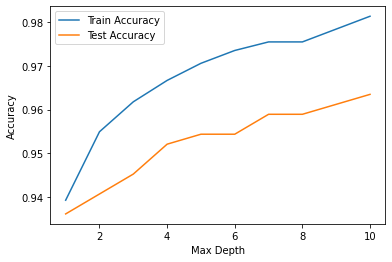

```python
import matplotlib.pyplot as plt

# Define a range of values to test for max_depth hyperparameter
max_depth_range = range(1, 11)

# Define empty lists to store the training and test accuracies
train_accs = []
test_accs = []

# Iterate over the range of max_depth values and fit a decision tree classifier
# with that value, and calculate the training and test accuracies for each value
for max_depth in max_depth_range:
    pipeline = make_pipeline(preprocessor, DecisionTreeClassifier(max_depth=max_depth))
    pipeline.fit(X_train, y_train)
    y_train_pred = pipeline.predict(X_train)
    y_test_pred = pipeline.predict(X_test)
    train_acc = accuracy_score(y_train, y_train_pred)
    test_acc = accuracy_score(y_test, y_test_pred)
    train_accs.append(train_acc)
    test_accs.append(test_acc)

# Plot the training and test accuracies for each max_depth value
plt.plot(max_depth_range, train_accs, label='Train Accuracy')
plt.plot(max_depth_range, test_accs, label='Test Accuracy')
plt.xlabel('Max Depth')
plt.ylabel('Accuracy')
plt.legend()
plt.show()
```

# **Conclusion**

[figure not shown]

```python
from IPython.display import display, Image
image_address = "/content/AI Assessment Form.png"
image = Image(filename=image_address, width=800)
display(image)
```